# MÁQUINA DE TURING

Teoría de la Computación  
2026-2

Walter Quispe Vargas

wquispev@utec.edu.pe  
Departamento de Ciencia de la Computación, UTEC

# CONTENIDO

- OBJETIVOS
- MÁQUINA DE TURING
  - Descripción de alto nivel
  - Ejercicios
- VARIANTES DE LA MÁQUINA DE TURING
  - Multicinta
  - No deterministica
- TESIS DE CHURCH-TURING
- CONCLUSIONES

# OBJETIVOS

- Diseñar una Máquina de Turing en alto nivel.
- Conocer Variantes de la Máquina de Turing
- Definir la Tesis de Church-Turing

## MÁQUINA DE TURING

DESCRIPCIÓN DE ALTO NIVEL:

- Es una forma `algorítmica` de describir a la M.T.
- EJEMPLO: Sea $L=\{w\#w|w\in\{0,1\}^*\}$
- Tarea: Diseñar una M.T. que reconozca dicho lenguaje.
- Estrategia?
- Las entradas pueden ser muy lagras para recordar, pero se permite mover el cabezal sobre la cinta y hacer marcas.
- ESTRATEGIA:
  - La M.T. hace zigzag sobre los lados del simbolo $\#$ para determinar si son iguales y hace marcas para recordar el lugar.
- Descripción de Alto Nivel:
- $M_1$ = Para la cadena $w$:
  1. Recorre la cinta en zigzag entre las posiciones correspondientes a ambos lados del símbolo $\#$ para verificar si contienen el mismo símbolo. Si no es así, o si no se encuentra ningún $\#$, **RECHAZA**
  2. Tacha los símbolos a medida que verifica para llevar un registro de cuáles se corresponden entre sí. Cuando se hayan tachado todos los símbolos a la izquierda del $\#$, comprueba si quedan símbolos a la derecha del $\#$. Si queda alguno, **RECHAZA**; de lo contrario, **ACEPTA**

## MÁQUINA DE TURING

- Sea $w=011000\#011000$
- La figura muestra algunas instancias no consecutivas de la cinta.

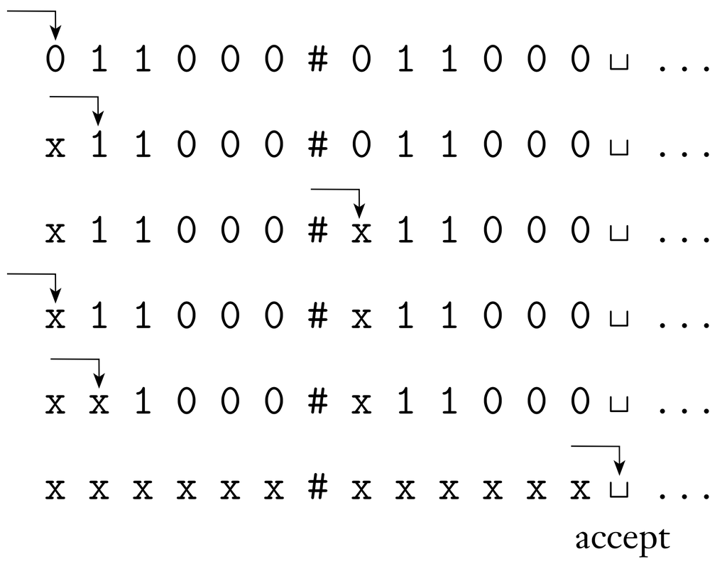

Tomado del libro: Introduction to Theory of Computer, Sipser

## MÁQUINA DE TURING

- DESCRIPCIÓN FORMAL:
- $M=(Q,\Sigma, \Gamma, \delta, q_0, q_a, q_r)$
- $Q=\{q_1,q_2,...,q_8,q_a,q_r\}$
- $\Sigma=\{0,1,\# \}$, $\Gamma = \{0,1,\#,\mbox{x},\sqcup\}$
- Estados: inicial = $q_1$, aceptación = $q_a$, rechazo = $q_r$
- $\delta$:

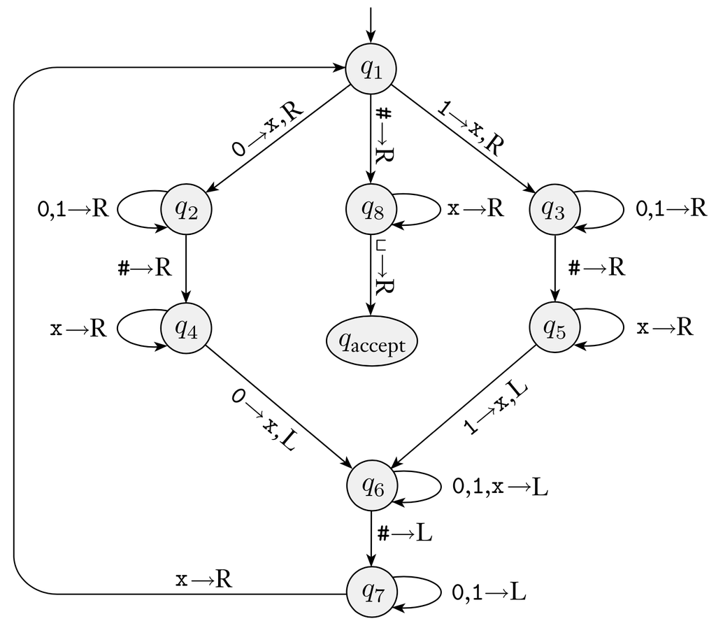

- Algunos ejemplos de NOTACIONES:
  - Usar: $0\rightarrow \mbox{x},R$, si $\delta(q_1,0)=(q_2,\mbox{x},R)$
  - Usar la abreviación: $\#\rightarrow R$ en lugar de $\#\rightarrow \#, R$, si $\delta(q_2,\#)=(q_4,\#,R)$
  - Usar: $0,1\rightarrow L$ en lugar de $0\rightarrow L$ y $1\rightarrow L$, si $\delta(q_7,0)=(q_7,0,L)$ y $\delta(q_7,1)=(q_7,1,L)$.
- OBSERVACIÓN:
- No se muestra el estado de rechazo $q_r$ ni las transciones que llevan a él por simplicidad.
- Dichas transiciones se producen implícitamente siempre que un estado carece de una transición de salida para un símbolo concreto.
- Ejemplo: en $q_5$ no existe ninguna flecha de salida con el símbolo $\#$, si este aparece bajo el cabezal, la máquina pasa al estado $q_r$ y el cabezal se desplaza hacia la derecha en cada una de estas transiciones al estado de rechazo.
- EJERCICIOS:
- Ejecutar la M.T. mediante sus configuraciónes para:
  - $\#$, $0\#0$, $1\#1$, $10\#10$, $11\#10$, $\epsilon$.

## MÁQUINA DE TURING

- EJERCICIOS:
- Dar la descripción de alto nivel para la M.T. que reconoce $\{0^{2^n}|n\geq 0\}$
- Ejecutar la M.T. mediante sus configuraciónes para:
  - $\epsilon$, $0$, $00$, $000$, $0000$.

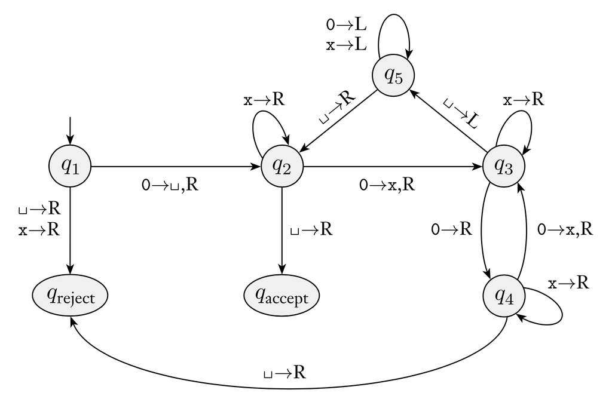

- $M =$ “Para la cadena de entrada w:s
  1. Recorrer la cinta de izquierda a derecha, tachando uno de cada dos ceros.
  2. Si en la etapa 1 la cinta contenía un único cero, aceptar.
  3. Si en la etapa 1 la cinta contenía más de un cero y el número de ceros era impar, rechazar.
  4. Devolver el cabezal al extremo izquierdo de la cinta.
  5. Ir a la etapa 1.”

## MÁQUINA DE TURING

DISEÑO formal y de alto nivel: En cada caso, construya una MT que haga lo pedido.

- Añade un 1 al final de la cadena y no modifica nada más
- Reemplaza el primer 0 por un 1
- Reemplaza todos los 0s por 1s
- Reconoce las cadenas que terminan en 0
- Reconoce cadenas con al menos dos 1s
- Reconoce cadenas con un número par de 1s
- Reconoce el lenguaje $\{0^{2n}1| n \geq 0\}$
- Reconoce el lenguaje $\{0^{2n}1^{n}| n \geq 0\}$
- Reconoce el lenguaje $\{0^{n}1^{n}2^{n}| n \geq 0\}$
- Reconoce $\{a^ib^jc^k|i\times j=k \mbox{ and } i,j,k \geq 1\}$

## VARIANTES DE LA M.T.

- Describimos variantes de la M.T.
- La M.T. original y las variantes son equivalentes
- La definición de la M.T. es robusta
- MÁQUINA DE TURING MULTICINTA
  - Cada cinta tiene su propio cabezal.
  - La cadena de entrada aparece en la primera cinta. las otras estan en blanco.
  - $\delta$ permite leer, escribir y mover los cabezales para algunas o todas las cintas simultaneamente, esto es:
  - $\delta: Q \times \Gamma^k \rightarrow Q \times \Gamma^k \times \{L,R\}^k$
    - $k$, es la cantidad de cintas.
- Por ejemplo, la expresión: $\delta(q_i,a_1,...,a_k)=(q_j,b_1,...,b_k,L,R,...,L)$
- Significa que, si la máquina se encuentra en el estado $q_i$ y los cabezales $1,2,...k$ están leyendo los símbolos $a_1,...,a_k$, la máquina pasa al estado $q_j$, escribe los símbolos $b_1,...,b_k$ y ordena a cada cabezal que se mueva a la izquierda o a la derecha, según se especifique.

## VARIANTES DE LA M.T.

- TEOREMA: Cualquier M.T. con varias cintas puede ser simulada con una M.T. con una cinta.
- Idea de la prueba: Sea $M$ la M.T. con varias cintas.
- Construir: una M.T. $S$ con una sola cinta, a partir de $M$
  - $S$ usa “$\#$” para delimitar los contenidos de las $k$ cintas.
  - $S$ usa “puntos” sobre los simbolos donde apuntan los $k$ cabezales “virtuales” ($\dot x$).
  - $S$ tiene $\Gamma' = \Gamma \cup \{\#\} \cup \{\dot x|x \in \Gamma\}$, donde $\Gamma$ es de $M$.

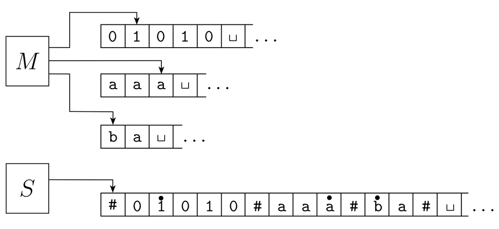

- $S$ = “Para la cadena $w=w_1w_2...w_n$
  1. En la cinta de $S$: $\# \dot w_1 w_2...w_n \#\dot \sqcup\#\dot \sqcup\ \#...\#$
  2. Para simular un movimiento, $S$ recorre su cinta desde el primer símbolo de la izquierda $\#$, hasta el $k+1$ símbolo de la derecha $\#$, para determinar los símbolos con punto bajo sus cabezales “virtuales”. Luego $S$ realiza un segundo recorrido para actualizar las cintas según $\delta$ de $M$
  3. Si en algún momento $S$ desplaza uno de los cabezales “virtuales” hacia la derecha hasta situarla sobre un símbolo $\#$, esto indica que $M$ ha movido dicho cabezal sobre la parte en blanco de la cinta que aún no se había leído. Luego, $S$ escribe blanco en esa celda y desplaza todo el contenido, desde dicha celda hasta el símbolo $\#$ más a la derecha. Luego, continua la simulación como antes”
- COROLARIO: Un lenguaje es Turing reconozible si y solo si alguna maquina de Turing multicinta lo reconoce.

## VARIANTES DE LA M.T.

- MÁQUINA DE TURING NO DETERMINISTICA.
  - En cualquier fase de la computación, la máquina puede proceder por multiples posibilidades.
  - $\delta: Q \times \Gamma \longrightarrow \mathcal{P}(Q \times \Gamma \times \{L,R\})$
  - Ejemplo: $\delta(q_0,0) = \{(q_1,0,R),(q_2,1,L),(q_3,0,R)\}$
- TEOREMA: Cualquier M.T. no deterministica puede ser simulada con una M.T. con una cinta.
- Idea de la prueba: Sea $N$: una M.T. no deterministica
- Construiremos una M.T. multicinta $D$ que simula todas las posibles ramas de computación de $N$.
- $D$ usa *breadth-first search* para garantizar visitar los nodos del árbol de computación hasta que encuentre una **configuración de aceptación**.
- En la busqueda, si $D$ encuentra una **configuración de aceptación** en una de estas ramas de computación de $N$, entonces $D$ **acepta**, caso contrario $D$ no determina.
- Diseño de $D$
  - $D$ tiene 3 cintas para simular $N$
    - Primera cinta: guarda la cadena de entrada y no se altera.
    - Segunda cinta: guarda una copia de la cinta de $N$ de alguna rama de su computación no deterministica.
    - Tercera cinta: guarda la dirección de la rama no determinista de $N$.

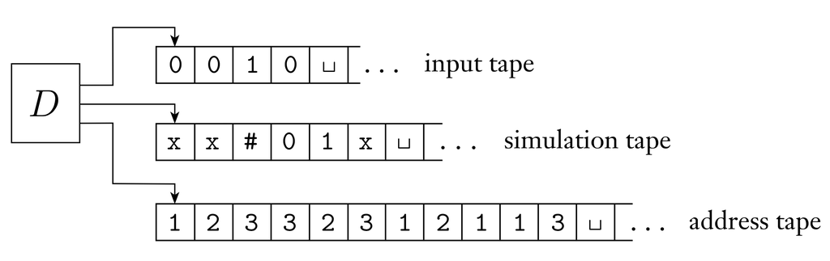

- La dirección 231 representa el nodo, al que llegamos iniciando en la raíz, pasando a su segundo hijo, luego al tercer hijo de este y finalmente al primer hijo del último.
- $D$ = “Para la cadena $w$
  1. La cinta 1 contiene $w$, las cintas 2 y 3 vacías.
  2. Copia la cinta 1 en la 2, inicializa la cadena en la cinta 3 como $\epsilon$
  3. Usa la cinta 2 para simular $N$ con $w$ en una rama de su computación no deterministica. Antes de cada paso de $N$ consulte el siguiente simbolo de la cinta 3 para determinar qué elección realizar entre las permitidas por $\delta$ de $N$. Si no queda más símbolos en la cinta 3 o si esta elección no determinista no es válida aborte la rama pasando al paso 4. Tambien si esta en una configuración de rechazo vaya al paso 4. Si esta en una configuración de aceptación, acepte $w$.
  4. Reemplaza la cadena de la cinta 3 por la siguiente cadena en el orden establecido. Simula la siguiente rama del cálculo de $N$ pasando al paso 2.
- COROLARIO: Un lenguaje es Turing reconozible si y solo si alguna maquina de Turing no deterministica lo reconoce.

## TESIS DE CHURCH Y TURING

- ${\tiny \text{Noción intuitiva de algoritmo} \equiv \text{Algoritmo expresable mediante una Máquina de Turing}}$
- **Cualquier problema que pueda ser resuelto mediante un procedimiento algorítmico o mecánico intuitivo puede ser resuelto por una Máquina de Turing**
- La **Tesis de Church-Turing** representa la identificación matemática y formal del concepto intuitivo de “algoritmo” o “procedimiento mecánico” con el modelo de la **Máquina de Turing**
- De manera informal, antes del siglo XX, un **algoritmo** se entendía como una colección de instrucciones simples o una “receta” para llevar a cabo una tarea paso a paso. Sin embargo, no existía una definición matemática precisa de lo que significaba que algo fuera “calculable de manera mecánica”
- En 1936 Alonzo Church (utilizando el sistema notacional del $\lambda$-cálculo) y Alan Turing (utilizando sus máquinas de Turing) definieron formalmente el concepto de algoritmo. Se demostró que ambos modelos, a pesar de sus diferencias de diseño, son exactamente equivalentes en poder de cómputo. Esta coincidencia dio origen a la Tesis de Church-Turing.
- ¿Por qué es una “Tesis” y no un “Teorema”?
  - Un **teorema** relaciona dos objetos matemáticos formales mediante una demostración lógica. En cambio, la Tesis de Church-Turing conecta: Un **concepto informal e intuitivo** (la noción humana de “procedimiento mecánico”) y un **concepto matemático formal** (la Máquina de Turing)
  - Dado que la “intuición humana” no se puede definir formalmente sin recurrir a un modelo, la tesis **no se puede demostrar matemáticamente**. Sin embargo, la evidencia a su favor es abrumadora debido a la **robustez** de los modelos de computación.
- Todos los modelos de computación razonables propuestos posteriormente (máquinas de Turing multicinta, no deterministas, autómatas celulares, modelos RAM, lenguajes de programación modernos como Python, C, Pascal o LISP) son **equivalentes en poder de cómputo** a la Máquina de Turing estándar. Ninguno ha demostrado ser más potente
- La Tesis de Church-Turing tiene dos consecuencias fundamentales:
  1. Permite usar Descripciones de Alto Nivel para Algoritmos.
     - Al saber que cualquier lenguaje de programación o pseudocódigo riguroso equivale a una Máquina de Turing, los *computer scientist* no necesitan programar extensos conjuntos de estados o transiciones de cinta a bajo nivel; basta con proporcionar una descripción clara en pseudocódigo.
  2. Permite Demostrar la Indecidibilidad de Problemas.
     - Gracias a esta definición formal de algoritmo, en 1970 Yuri Matijasevič (basándose en trabajos previos de Davis, Putnam y Robinson) pudo demostrar formalmente que el **Décimo Problema de Hilbert es indecidible** (no existe ningún algoritmo que pueda resolverlo).
     - Permite demostrar la indecidibilidad de problemas centrales como el **Problema de la Parada** ($A_{TM}$)

## TERMINOLOGÍA PARA DESCRIBIR MT

- ENTRADA DE UNA M.T.: $w\in \Sigma^*$.
- En la Práctica, las entradas son “**OBJETOS**” abstractos como:
  - Listas: $L$, Grafos: $G$, Polinomios: $p$, Autómatas: $AFD, AFN, AP$, Gramáticas: $GLC$, Máquinas de Turing $M.T.$, etc.
- Para que una M.T.: pueda procesar un **objeto abstracto** $O$, este debe representarse como una **cadena** de texto o **bits**.
- Este proceso de conversión: de un objeto abstracto a su representación en forma de cadena se le denomina **codificación**.
- NOTACIÓN:
  - Objeto individual: $\langle O \rangle$
  - Múltiples objetos: $\langle O_1, O_2, \dots, O_k \rangle$
- El método de codificación no altera los resultados teóricos de decidibilidad ni reconocibilidad.
  - Se puede elegir cualquier representación que sea “razonable” (por ejemplo, representar un grafo mediante una matriz de adyacencia o mediante una lista de pares de nodos).
- JUSTIFICACIÓN: Una Máquina de Turing siempre puede ser programada para traducir eficientemente de una codificación a otra. Por lo tanto, no es necesario especificar los detalles binarios o alfabéticos de bajo nivel en las descripciones de los algoritmos.
- CONCLUCIÓN: La codificación $\langle O \rangle$ es el mecanismo que permite elevar el **nivel de abstracción** en la teoría de la computación. Permite hablar formalmente de algoritmos que procesan objetos matemáticos complejos en Máquinas de Turing sin perder el rigor de que la máquina solo opera sobre cadenas.

## CONCLUSIONES

### En esta sesión aprendiste

- A describir la máquina de Turing en lato nivel.
- Las variantes de una máquina de Turing.
  - Multicinta.
  - No determiistica.
- La tesis de Church-Turing.